# Final Project

#### Jen McIver - 18/11/24

## Contents

1. Importing packages and files
- Define brand colours
2. Data Inspection and Cleaning
3. Explore the data, find totals and trends
- Monthly Revenue Comparison
- Full Year Revenue Comparison
- YTD Comparison for all years
- Top 5 commodities of each year by count
- Top 5 commodities of each month by count
- Highest revenue commodities of each year
- Highest revenue commodities by month
- Total basket count by year (excluding current ytd)
- Total basket count for first 5 months of each year
- Count of baskets by each loyalty group
- Count of baskets each household type
- Which brand generates the most revenue?
- Household type stats
- Loyalty group stats
- Age band stats
- Average price of the highest revenue commodities by year and month
- Average Price of Top Selling Commodities by Year
- What loyalty group spends the most per shop (breakdown per year)?
4. Analyse and chart the data to answer the business questions
- Group the most popular commodities in to Product Groups
- Stats for the most popular Product Groups
- Pie charts for Household Type purchases
- Pie charts for Age band purchases
- Sales Revenue Chart
- Compare Sales revenue for first 5 months of all 4 years
- Show total baskets per year have stayed consistent
- Create data set for ytd comparison of revenue for focus products
- Chart revenue of focus products for the first 5 months of each year in the data set
- Average monthly revenue for each of the focus products since 2019
- Average spend per basket for each of the focus products for the last 6 months
- Required revenue increase calculation
- How many additional cheese, deli and seafood purchases do we need per month to achieve our goal?
- How many additional shops per month are required by customers in the 19-24 age group to achieve our goal?

## Importing packages and files

```python
import pandas as pd
import numpy as np
import math
import matplotlib.pyplot as plt
from matplotlib.ticker import FuncFormatter
import matplotlib.colors as mcolors
import seaborn as sns
import os
```

```python
### Change working directory
os.chdir('C:\\Users\\jen.mciver_aroflo\\Documents\\Coursework\\SQL and Python\\Final\\')
os.getcwd()
```

```
'C:\\Users\\jen.mciver_aroflo\\Documents\\Coursework\\SQL and Python\\Final'
```

```python
df1 = pd.read_csv('dataset_2019_2022.csv')
#, parse_dates=['transaction_date'], date_parser=lambda d: pd.Timestamp(d).strftime('%d,%m,%Y'))
df1.head()
```

|  | customer_id | product_id | basket_id | loyalty | household_type | age_band | department | brand | commodity | store | price | transaction_date |
| --- | --- | --- | --- | --- | --- | --- | --- | --- | --- | --- | --- | --- |
| 0 | 15803 | 1131974 | 57266 | Loyalist | 1 adult with kids | 19-24 | Grocery | private | Baked bread/buns/rolls | 374 | 0.99 | 5/10/2020 |
| 1 | 15803 | 1051516 | 57266 | Loyalist | 1 adult with kids | 19-24 | Produce | national | Vegetables - all others | 374 | 0.70 | 24/10/2020 |
| 2 | 15803 | 967254 | 57266 | Loyalist | 1 adult with kids | 19-24 | Pharmaceutical | national | Cold and flu | 374 | 1.68 | 18/10/2020 |
| 3 | 15803 | 1134222 | 57266 | Loyalist | 1 adult with kids | 19-24 | Grocery | private | Paper housewares | 374 | 2.59 | 23/10/2020 |
| 4 | 15803 | 1003421 | 57266 | Loyalist | 1 adult with kids | 19-24 | Grocery | national | Soup | 374 | 0.60 | 27/10/2020 |

### Define brand colours

```python
# Define brand colors as hex values
brand_colors = {
    'sea green': '#01b59a',
    'deep sky blue': '#00a3d9',
    'orchid': '#d07cb3',
    'periwinkle': '#6667AB',
    'peacoat': '#383749',
    'chartreuse': '#e2e419',
    'lt sea green': '#80dfd5',
    'lt sky blue': '#80d2ec',
    'lt orchid': '#e8b9d4',
    'lt periwinkle': '#9f9fc6',
    'lt peacoat': '#9c99a7',
    'lt chartreuse': '#f4f68d'
}
```

## Data Inspection and Cleaning

```python
### show statistics about data set
df1.describe(include='all')
```

|  | customer_id | product_id | basket_id | loyalty | household_type | age_band | department | brand | commodity | store | price | transaction_date |
| --- | --- | --- | --- | --- | --- | --- | --- | --- | --- | --- | --- | --- |
| count | 7.775000e+04 | 7.775000e+04 | 7.775000e+04 | 77750 | 77750 | 77750 | 77750 | 77750 | 77750 | 77750.0 | 77750.000000 | 77750 |
| unique | NaN | NaN | NaN | 3 | 5 | 6 | 11 | 2 | 247 | NaN | NaN | 1246 |
| top | NaN | NaN | NaN | Promiscuous | 2 adults with kids | 19-24 | Grocery | national | Beef | NaN | NaN | 28/02/2022 |
| freq | NaN | NaN | NaN | 44943 | 22820 | 39658 | 25516 | 59884 | 2944 | NaN | NaN | 109 |
| mean | 2.425159e+04 | 3.579019e+06 | 6.905152e+04 | NaN | NaN | NaN | NaN | NaN | NaN | 374.0 | 3.231060 | NaN |
| std | 3.965495e+04 | 4.714247e+06 | 1.055748e+05 | NaN | NaN | NaN | NaN | NaN | NaN | 0.0 | 3.280044 | NaN |
| min | 1.580300e+04 | 3.508200e+04 | 5.196400e+04 | NaN | NaN | NaN | NaN | NaN | NaN | 374.0 | 0.100000 | NaN |
| 25% | 1.952900e+04 | 9.200910e+05 | 5.987200e+04 | NaN | NaN | NaN | NaN | NaN | NaN | 374.0 | 1.490000 | NaN |
| 50% | 2.342900e+04 | 1.037863e+06 | 6.802100e+04 | NaN | NaN | NaN | NaN | NaN | NaN | 374.0 | 2.500000 | NaN |
| 75% | 2.699300e+04 | 5.578437e+06 | 7.521500e+04 | NaN | NaN | NaN | NaN | NaN | NaN | 374.0 | 3.990000 | NaN |
| max | 2.811700e+06 | 1.820392e+07 | 6.811600e+06 | NaN | NaN | NaN | NaN | NaN | NaN | 374.0 | 68.970000 | NaN |

```python
### Check for null values and data types
df1.info()
```

```
<class 'pandas.core.frame.DataFrame'>
RangeIndex: 77750 entries, 0 to 77749
Data columns (total 12 columns):
 #   Column            Non-Null Count  Dtype
---  ------            --------------  -----
 0   customer_id       77750 non-null  int64
 1   product_id        77750 non-null  int64
 2   basket_id         77750 non-null  int64
 3   loyalty           77750 non-null  object
 4   household_type    77750 non-null  object
 5   age_band          77750 non-null  object
 6   department        77750 non-null  object
 7   brand             77750 non-null  object
 8   commodity         77750 non-null  object
 9   store             77750 non-null  int64
 10  price             77750 non-null  float64
 11  transaction_date  77750 non-null  object
dtypes: float64(1), int64(4), object(7)
memory usage: 7.1+ MB
```

```python
### Check for NaN values
nan_check_df1 = np.nonzero(df1.isnull())
print(nan_check_df1)
```

```
(array([], dtype=int64), array([], dtype=int64))
```

```python
### Convert Date Format to datetime
### Add Year and Month fields
df1.transaction_date = pd.to_datetime(df1.transaction_date, dayfirst=True)
df1['year'] = df1.transaction_date.dt.year
df1['month'] = df1.transaction_date.dt.month
df1.head()
```

|  | customer_id | product_id | basket_id | loyalty | household_type | age_band | department | brand | commodity | store | price | transaction_date | year | month |
| --- | --- | --- | --- | --- | --- | --- | --- | --- | --- | --- | --- | --- | --- | --- |
| 0 | 15803 | 1131974 | 57266 | Loyalist | 1 adult with kids | 19-24 | Grocery | private | Baked bread/buns/rolls | 374 | 0.99 | 2020-10-05 | 2020 | 10 |
| 1 | 15803 | 1051516 | 57266 | Loyalist | 1 adult with kids | 19-24 | Produce | national | Vegetables - all others | 374 | 0.70 | 2020-10-24 | 2020 | 10 |
| 2 | 15803 | 967254 | 57266 | Loyalist | 1 adult with kids | 19-24 | Pharmaceutical | national | Cold and flu | 374 | 1.68 | 2020-10-18 | 2020 | 10 |
| 3 | 15803 | 1134222 | 57266 | Loyalist | 1 adult with kids | 19-24 | Grocery | private | Paper housewares | 374 | 2.59 | 2020-10-23 | 2020 | 10 |
| 4 | 15803 | 1003421 | 57266 | Loyalist | 1 adult with kids | 19-24 | Grocery | national | Soup | 374 | 0.60 | 2020-10-27 | 2020 | 10 |

```python
### Convert all string values to lower case
# Note that I missed age band!

df1['loyalty'] = df1['loyalty'].str.lower()
df1['household_type'] = df1['household_type'].str.lower()
df1['department'] = df1['department'].str.lower()
df1['brand'] = df1['brand'].str.lower()
df1['commodity'] = df1['commodity'].str.lower()
df1.head()
```

|  | customer_id | product_id | basket_id | loyalty | household_type | age_band | department | brand | commodity | store | price | transaction_date | year | month |
| --- | --- | --- | --- | --- | --- | --- | --- | --- | --- | --- | --- | --- | --- | --- |
| 0 | 15803 | 1131974 | 57266 | loyalist | 1 adult with kids | 19-24 | grocery | private | baked bread/buns/rolls | 374 | 0.99 | 2020-10-05 | 2020 | 10 |
| 1 | 15803 | 1051516 | 57266 | loyalist | 1 adult with kids | 19-24 | produce | national | vegetables - all others | 374 | 0.70 | 2020-10-24 | 2020 | 10 |
| 2 | 15803 | 967254 | 57266 | loyalist | 1 adult with kids | 19-24 | pharmaceutical | national | cold and flu | 374 | 1.68 | 2020-10-18 | 2020 | 10 |
| 3 | 15803 | 1134222 | 57266 | loyalist | 1 adult with kids | 19-24 | grocery | private | paper housewares | 374 | 2.59 | 2020-10-23 | 2020 | 10 |
| 4 | 15803 | 1003421 | 57266 | loyalist | 1 adult with kids | 19-24 | grocery | national | soup | 374 | 0.60 | 2020-10-27 | 2020 | 10 |

## Explore the data, find totals and trends

```python
### Check date ranges of values from each year
df1.groupby(['year']).agg(start_month=('month', 'min'), end_month=('month', 'max')).head()
```

| year | start_month | end_month |
| --- | --- | --- |
| 2019 | 1 | 12 |
| 2020 | 1 | 12 |
| 2021 | 1 | 12 |
| 2022 | 1 | 5 |

### Monthly Revenue Comparison

```python
### Total revenue by month
tot_monthly_rev = df1.groupby(['year', 'month']).agg(monthly_rev=('price', 'sum')).reset_index()
tot_monthly_rev.head(50)
```

|  | year | month | monthly_rev |
| --- | --- | --- | --- |
| 0 | 2019 | 1 | 5287.93 |
| 1 | 2019 | 2 | 5738.20 |
| 2 | 2019 | 3 | 6295.21 |
| 3 | 2019 | 4 | 5804.32 |
| 4 | 2019 | 5 | 5461.15 |
| 5 | 2019 | 6 | 7206.28 |
| 6 | 2019 | 7 | 7107.16 |
| 7 | 2019 | 8 | 6790.37 |
| 8 | 2019 | 9 | 5264.79 |
| 9 | 2019 | 10 | 5369.17 |
| 10 | 2019 | 11 | 5727.65 |
| 11 | 2019 | 12 | 6679.53 |
| 12 | 2020 | 1 | 5366.78 |
| 13 | 2020 | 2 | 5861.81 |
| 14 | 2020 | 3 | 5929.93 |
| 15 | 2020 | 4 | 6487.92 |
| 16 | 2020 | 5 | 5679.71 |
| 17 | 2020 | 6 | 6962.57 |
| 18 | 2020 | 7 | 7442.96 |
| 19 | 2020 | 8 | 6422.34 |
| 20 | 2020 | 9 | 5362.16 |
| 21 | 2020 | 10 | 5354.23 |
| 22 | 2020 | 11 | 6095.60 |
| 23 | 2020 | 12 | 7246.30 |
| 24 | 2021 | 1 | 5462.93 |
| 25 | 2021 | 2 | 5289.52 |
| 26 | 2021 | 3 | 6109.74 |
| 27 | 2021 | 4 | 6394.11 |
| 28 | 2021 | 5 | 6464.49 |
| 29 | 2021 | 6 | 7665.36 |
| 30 | 2021 | 7 | 6506.25 |
| 31 | 2021 | 8 | 6909.86 |
| 32 | 2021 | 9 | 5299.70 |
| 33 | 2021 | 10 | 5288.93 |
| 34 | 2021 | 11 | 5573.33 |
| 35 | 2021 | 12 | 7371.65 |
| 36 | 2022 | 1 | 5242.21 |
| 37 | 2022 | 2 | 6240.52 |
| 38 | 2022 | 3 | 5835.69 |
| 39 | 2022 | 4 | 6380.56 |
| 40 | 2022 | 5 | 6235.96 |

### Full Year Revenue Comparison

```python
### Total revenue by year (excluding current ytd)
#Find years included in dataframe
full_years = df1.groupby('year')['month'].nunique()
# Filter for years with all 12 months
fy = sorted(full_years[full_years == 12].index.tolist())
#print(fy)
df1_fullyears = df1[df1['year'].isin(fy)]
#df1_fullyears.head(50)
rev_fullyears = df1_fullyears.groupby(['year']).agg(total_revenue=('price', 'sum'))
rev_fullyears.head()
```

| year | total_revenue |
| --- | --- |
| 2019 | 72731.76 |
| 2020 | 74212.31 |
| 2021 | 74335.87 |

### YTD Comparison for all years

```python
### Total revenue for first 6 months of each year

# Group the dataframe by year and find the months for each year
months_per_year = df1.groupby('year')['month'].apply(set)

# Find the intersection of all month sets
fm = set.intersection(*months_per_year)

# Convert to a sorted list
fm = sorted(fm)

ytd=df1[df1.month.isin(fm)]
rev_ytd = ytd.groupby(['year']).agg(total_revenue=('price', 'sum'))
rev_ytd.head()
```

| year | total_revenue |
| --- | --- |
| 2019 | 28586.81 |
| 2020 | 29326.15 |
| 2021 | 29720.79 |
| 2022 | 29934.94 |

### Top 5 commodities of each year by count

```python
# Group by year and commodity, sort by count of occurrences
bc = df1.groupby(['year', 'commodity']).agg(total_purchases=('basket_id', 'count')) \
    .sort_values(['year', 'total_purchases'], ascending=[True, False]).reset_index()

# Group by year and take the top 5 commodities for each year
top5_cy = bc.groupby('year').head(5).reset_index(drop=True)
top5_cy['rank'] = top5_cy.groupby('year')['total_purchases'].rank(method='first', ascending=False)
#top5_cy.head(60)

# Pivot
pivoted_top5_cy = top5_cy.pivot(index='rank', columns='year', values='commodity')
pivoted_top5_cy.head()
```

| year rank | 2019 | 2020 | 2021 | 2022 |
| --- | --- | --- | --- | --- |
| 1.0 | beef | beef | beef | candy |
| 2.0 | candy | candy | candy | beef |
| 3.0 | tropical fruit | tropical fruit | lunch meat | deli meats |
| 4.0 | cheese | lunch meat | tropical fruit | cheese |
| 5.0 | salad | cheese | cheese | salad |

### Top 5 commodities of each month by count

```python
# Group by month and commodity, sort by count of occurrences

bc_month = df1.groupby(['month', 'commodity']).agg(total_purchases=('basket_id', 'count')) \
    .sort_values(['month', 'total_purchases'], ascending=[True, False]).reset_index()


# Group by month and take the top 5 commodities for each month
top5_cm = bc_month.groupby('month').head(5).reset_index(drop=True)
top5_cm['rank'] = top5_cm.groupby('month')['total_purchases'].rank(method='first', ascending=False)
#top5_cm.head(60)
# Pivot
pivoted_top5_cm = top5_cm.pivot(index='rank', columns='month', values='commodity')
pivoted_top5_cm.head(50)
```

| month rank | 1 | 2 | 3 | 4 | 5 | 6 | 7 | 8 | 9 | 10 | 11 | 12 |
| --- | --- | --- | --- | --- | --- | --- | --- | --- | --- | --- | --- | --- |
| 1.0 | candy | candy | cheese | salad | beef | beef | tropical fruit | candy | candy | beef | beef | beef |
| 2.0 | beef | beef | beef | beef | candy | candy | lunch meat | tropical fruit | beef | candy | salad | lunch meat |
| 3.0 | breakfast sweets | tropical fruit | candy | candy | salad | cheese | candy | lunch meat | tropical fruit | tropical fruit | bread | cheese |
| 4.0 | lunch meat | salad | lunch meat | deli meats | deli meats | lunch meat | cheese | beef | salad | salad | cheese | frozen meat |
| 5.0 | tropical fruit | deli meats | tropical fruit | breakfast sweets | lunch meat | tropical fruit | beef | cheese | breakfast sweets | soft drinks | soft drinks | soft drinks |

### Highest revenue commodities of each year

```python
# Group by year and commodity, sort by sum of price
rev_yr = df1.groupby(['year', 'commodity']).agg(total_revenue=('price', 'sum')) \
    .sort_values(['year', 'total_revenue'], ascending=[True, False]).reset_index()

# Group by year and take the top 5 commodities for each year
top5_ry = rev_yr.groupby('year').head(5).reset_index(drop=True)
top5_ry['rank'] = top5_ry.groupby('year')['total_revenue'].rank(method='first', ascending=False)
#top5_ry.head(60)

# Pivot
pivoted_top5_ry = top5_ry.pivot(index='rank', columns='year', values='commodity')
pivoted_top5_ry.head()
```

| year rank | 2019 | 2020 | 2021 | 2022 |
| --- | --- | --- | --- | --- |
| 1.0 | beef | beef | beef | beef |
| 2.0 | cheese | frozen meat | lunch meat | seafood-frozen |
| 3.0 | seafood-frozen | cheese | cheese | deli meats |
| 4.0 | frozen meat | lunch meat | salad | frozen meat |
| 5.0 | salad | salad | deli meats | cigarettes |

### Highest revenue commodities by month

```python
# Group by month and commodity, sort by count of occurrences

rev_month = df1.groupby(['month', 'commodity']).agg(total_revenue=('price', 'sum')) \
    .sort_values(['month', 'total_revenue'], ascending=[True, False]).reset_index()


# Group by month and take the top 5 commodities for each month
top5_cm = rev_month.groupby('month').head(5).reset_index(drop=True)
top5_cm['rank'] = top5_cm.groupby('month')['total_revenue'].rank(method='first', ascending=False)
#top5_cm.head(60)
# Pivot
pivoted_top5_cm = top5_cm.pivot(index='rank', columns='month', values='commodity')
pivoted_top5_cm.head(50)
```

| month rank | 1 | 2 | 3 | 4 | 5 | 6 | 7 | 8 | 9 | 10 | 11 | 12 |
| --- | --- | --- | --- | --- | --- | --- | --- | --- | --- | --- | --- | --- |
| 1.0 | beef | beef | beef | beef | beef | beef | beef | beef | beef | beef | beef | beef |
| 2.0 | frozen meat | seafood-fresh | seafood-frozen | salad | deli meats | pork | lunch meat | seafood-frozen | chicken | deli meats | cigarettes | frozen meat |
| 3.0 | soft drinks | seafood-frozen | cheese | deli meats | salad | cigarettes | cheese | cheese | vitamins | salad | pork | cheese |
| 4.0 | lunch meat | cigarettes | meat - other | frozen meat | chicken | cakes | seafood-frozen | frozen meat | frozen meat | meat - other | chicken | lunch meat |
| 5.0 | candy | candy | breakfast sausage/sandwiches | seafood-frozen | lunch meat | cheese | pork | lunch meat | salad | frozen meat | cakes | pork |

### Total basket count by year (excluding current ytd)

```python
tot_bc = df1_fullyears.groupby(['year']).agg(total_baskets=('basket_id', pd.Series.nunique)).reset_index()
tot_bc.head()
```

|  | year | total_baskets |
| --- | --- | --- |
| 0 | 2019 | 1016 |
| 1 | 2020 | 1032 |
| 2 | 2021 | 1037 |

```python
tot_bc_month = ytd.groupby(['month']).agg(total_baskets=('basket_id', pd.Series.nunique)).reset_index()
tot_bc_month.head()
```

|  | month | total_baskets |
| --- | --- | --- |
| 0 | 1 | 298 |
| 1 | 2 | 337 |
| 2 | 3 | 330 |
| 3 | 4 | 337 |
| 4 | 5 | 318 |

### Count of baskets by each loyalty group

```python
tot_loy = df1.groupby(['loyalty']).agg(total_purchases=('basket_id', pd.Series.nunique)) \
    .sort_values('total_purchases', ascending=False).reset_index()
tot_loy.head()
```

|  | loyalty | total_purchases |
| --- | --- | --- |
| 0 | promiscuous | 2033 |
| 1 | loyalist | 1413 |
| 2 | first time buyer | 52 |

### Count of baskets each household type

```python
tot_hh = df1.groupby(['household_type']).agg(total_purchases=('basket_id', pd.Series.nunique)) \
    .sort_values('total_purchases', ascending=False).reset_index()
tot_hh.head()
```

|  | household_type | total_purchases |
| --- | --- | --- |
| 0 | 2 adults with kids | 1044 |
| 1 | 1 adult with kids | 844 |
| 2 | 2 adults with no kids | 766 |
| 3 | single male | 539 |
| 4 | single female | 305 |

### Which brand generates the most revenue?

```python
brand_rev = df1.groupby(['brand']).agg(total_revenue=('price', 'sum'), count_of_commodities=('commodity', pd.Series.nunique), \
    avg_price=('price', 'mean')).sort_values('total_revenue', ascending=False).reset_index()
brand_rev.head()
```

|  | brand | total_revenue | count_of_commodities | avg_price |
| --- | --- | --- | --- | --- |
| 0 | national | 201482.76 | 241 | 3.364551 |
| 1 | private | 49732.12 | 163 | 2.783618 |

NOTES:

- Looks like national brands are more popular
- Note: the average price above is not per unique commodity
- Also curious if the national brand is more popular with a certain household type or age band - added that as a criteria below

### Household type stats

```python
#Revenue, Basket Count, preferred brand, preferred commodity
hh_stats = df1.groupby(['household_type']).agg(total_revenue=('price', 'sum'), count_of_commodities=('commodity', pd.Series.nunique), \
    pref_brand=('brand', lambda x: x.mode()[0]), pref_com=('commodity', lambda x: x.mode()[0])).sort_values('total_revenue', ascending=False).reset_index()
hh_stats.head()
```

|  | household_type | total_revenue | count_of_commodities | pref_brand | pref_com |
| --- | --- | --- | --- | --- | --- |
| 0 | 2 adults with kids | 73075.59 | 246 | national | beef |
| 1 | 1 adult with kids | 60847.26 | 241 | national | beef |
| 2 | 2 adults with no kids | 55455.15 | 244 | national | beef |
| 3 | single male | 39440.96 | 240 | national | candy |
| 4 | single female | 22395.92 | 229 | national | beef |

### Loyalty group stats

```python
#Revenue, Basket Count, preferred brand, preferred commodity
loy_stats = df1.groupby(['loyalty']).agg(total_revenue=('price', 'sum'), count_of_commodities=('commodity', pd.Series.nunique), \
    pref_brand=('brand', lambda x: x.mode()[0]), pref_com=('commodity', lambda x: x.mode()[0])).sort_values('total_revenue', ascending=False).reset_index()
loy_stats.head()
```

|  | loyalty | total_revenue | count_of_commodities | pref_brand | pref_com |
| --- | --- | --- | --- | --- | --- |
| 0 | promiscuous | 145365.55 | 247 | national | beef |
| 1 | loyalist | 102324.80 | 242 | national | candy |
| 2 | first time buyer | 3524.53 | 186 | national | candy |

### Age band stats

```python
# Revenue, Basket Count, preferred brand, preferred commodity
age_stats = df1.groupby(['age_band']).agg(total_revenue=('price', 'sum'), count_of_commodities=('commodity', pd.Series.nunique), \
    pref_brand=('brand', lambda x: x.mode()[0]), pref_com=('commodity', lambda x: x.mode()[0])).sort_values('total_revenue', ascending=False).reset_index()
age_stats.head()
```

|  | age_band | total_revenue | count_of_commodities | pref_brand | pref_com |
| --- | --- | --- | --- | --- | --- |
| 0 | 19-24 | 129514.46 | 247 | national | beef |
| 1 | 45-54 | 64142.33 | 245 | national | beef |
| 2 | 25-34 | 41374.53 | 237 | national | candy |
| 3 | 35-44 | 15307.18 | 214 | national | tropical fruit |
| 4 | 55-64 | 450.64 | 86 | national | beef |

### Average price of the highest revenue commodities by year and month

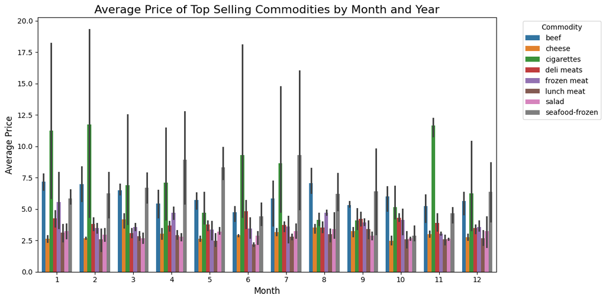

```python
# Filter df1 for only rows where the commodity is one of the top 5
df1_top5 = df1[df1['commodity'].isin(top5_ry['commodity'])].reset_index(drop=True)
top5_avg_prices = df1_top5.groupby(['year', 'month', 'commodity']).agg(avg_price=('price', 'mean')).reset_index()
#top5_avg_prices.head(50)

# Create the bar chart using Seaborn
plt.figure(figsize=(12, 6))

sns.barplot(
    data=top5_avg_prices,
    x='month',
    y='avg_price',
    hue='commodity'
)

plt.title('Average Price of Top Selling Commodities by Month and Year', fontsize=16)
plt.xlabel('Month', fontsize=12)
plt.ylabel('Average Price', fontsize=12)
plt.legend(title='Commodity', bbox_to_anchor=(1.05, 1), loc='upper left')
plt.xticks(fontsize=10)
plt.yticks(fontsize=10)

plt.tight_layout()
plt.show()
```

NOTES:

- I like the general format of the chart but its unreadable
- I want to try to split it out by year

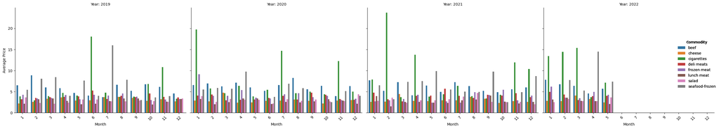

```python
# Create a FacetGrid with separate subplots for each year
g = sns.catplot(
    data=top5_avg_prices,
    x='month',
    y='avg_price',
    hue='commodity',
    col='year',            # This is what separates the plots by what ever field is specified
    kind='bar',
    height=5,              # Height of each subplot
    aspect=1.2             # Aspect ratio of each subplot
)

# Customize the overall plot
g.set_titles("Year: {col_name}")  # Sets title for each subplot
g.set_axis_labels("Month", "Average Price")  # Sets common axis labels
g.set_xticklabels(rotation=45)  # Rotates x-axis labels for clarity
g.add_legend(title="Commodity")  # Adds a legend to the plot

# Display
plt.tight_layout()
plt.show()
```

NOTES:

- Ok, that's kind of awesome, but I still can't read it
- Trying to create a separate plot per year

```python
# Loop through each unique year in the data
# Function to format y-axis as currency
def currency_format(x, _):
    return f'${x:,.2f}'  # Formats with a dollar sign, commas, and two decimal places


for year in fy:
# Filter data for the specific year
    year_data = top5_avg_prices[top5_avg_prices['year'] == year]

# Create the bar chart
    plt.figure(figsize=(10, 6))
    sns.barplot(
        data=year_data,
        x='month',
        y='avg_price',
        hue='commodity'
    )

# Customize the chart
    plt.title(f'Average Price of Top 5 Commodities in {year}', fontsize=16)
    plt.xlabel('Month', fontsize=12)
    plt.ylabel('Average Price', fontsize=12)
    plt.gca().yaxis.set_major_formatter(FuncFormatter(currency_format))  # Apply currency format to y-axis
    plt.legend(title='Commodity', loc='upper left', bbox_to_anchor=(1, 1))
    plt.xticks(fontsize=10)
    plt.yticks(fontsize=10)

# Display the chart
#    plt.tight_layout()
#    plt.show()

# Save the chart as an image file
    filename = f'.\\Charts\\avgprice_monthly-top5_{year}.png'  # Create a unique filename for each year
    plt.tight_layout()
    plt.savefig(filename, dpi=300)  # Save with high resolution (300 dpi)
    plt.close()  # Close the current figure to free memory

print("Charts Saved")
```

```
Charts Saved
```

NOTES:

- Separate charts are better
- I am questioning whether my average price calculation is correct. Double-checking my code - may check via excel as well. **DONE - looks right, but the data has some pretty extreme outlier numbers that are driving up the average.**
- Also want to go back and redo the first chart to just show years **DONE**

### Average Price of Top Selling Commodities by Year

NOTES:

- This is the chart that gave me the info I needed to focus in on the products that were most likely to generate revenue.

```python
### Start with redoing my first chart

# Map commodities to specific brand colors
commodity_color_map = {
    'beef': brand_colors['periwinkle'],
    'cheese': brand_colors['chartreuse'],
    'cigarettes': brand_colors['peacoat'],
    'deli meats': brand_colors['orchid'],
    'frozen meat': brand_colors['lt periwinkle'],
    'lunch meat': brand_colors['deep sky blue'],
    'salad': brand_colors['lt sea green'],
    'seafood-frozen': brand_colors['lt orchid']
}

plt.figure(figsize=(12, 6))

sns.barplot(
    data=top5_avg_prices,
    x='year',
    y='avg_price',
    hue='commodity',
    palette=commodity_color_map
)

plt.title('Average Price of Top Selling Commodities by Year', fontsize=16)
plt.xlabel('Year', fontsize=12)
plt.ylabel('Average Price', fontsize=12)
plt.gca().yaxis.set_major_formatter(FuncFormatter(currency_format))  # Apply currency format to y-axis
plt.legend(title='Commodity', bbox_to_anchor=(1.05, 1), loc='upper left')
plt.xticks(fontsize=10)
plt.yticks(fontsize=10)

# Save the chart as an image file
filename = f'.\\Charts\\avgprice_yearly-top5.png'
plt.tight_layout()
plt.savefig(filename, dpi=300)
plt.close()

print("Charts Saved")

#plt.tight_layout()
#plt.show()
```

```
Charts Saved
```

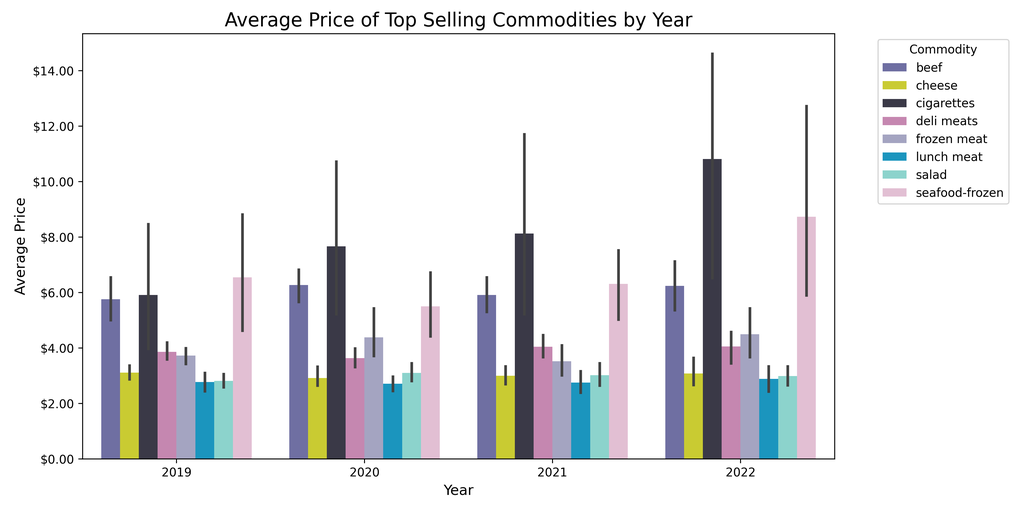

NOTES:

- Cigarettes have the most fluctuation in price, frozen seafood fluctuates as well
- Least fluctuation in salad, cheese, beef, deli meats
- If we are going to promote sales of items over a long period, we would be better off promoting items with more reliable revenue. Seafood prices are currently high, though, and as a short term promotion would be lucrative
- Increasing sales of our popular beef and seafood products, given they also have higher revenue would be useful. Recommendation to make those products even more visible, improve the aesthetics of the meat and seafood counters
- Do private brands bring in more revenue? If so we should place more of them at eye level
- Check consistency of all fresh meat and seafood products over time. Is that where to focus the renovations?
- Add grab and go salad offering
- Improve deli meat and cheese counters

**MARKET RESEARCH - MOST PROFITABLE GROCERY ITEMS**

- Cheese - 35%
- Deli Meat - annual growth rate of 7.78%
- High Quality Produce - 30%
- Prepared Meals - can charge higher markups
- Frozen Foods - long shelf life, less wastage
- Paired Items - offer complementary products together (dressings near salads, etc)
- Cereal - 28% markup average, long shelf life

```python
basket_spend = df1.groupby(['loyalty', 'basket_id']).agg(total_spend=('price', 'sum')).reset_index()
# Find the average total spend per basket for each loyalty group
loy_avg_spend = basket_spend.groupby('loyalty').agg(avg_shop_spend=('total_spend', 'mean')).sort_values('avg_shop_spend', ascending=False).reset_index()
loy_avg_spend.head()
```

|  | loyalty | avg_shop_spend |
| --- | --- | --- |
| 0 | loyalist | 72.416702 |
| 1 | promiscuous | 71.502976 |
| 2 | first time buyer | 67.779423 |

## Analyse and chart the data to answer the business questions

### Group the most popular commodities in to Product Groups

```python
### Find seafood commodities
search_terms = ["seafood", "fish", "shrimp", "prawn"]
pattern = "|".join(search_terms)
df1_seafood = df1[df1['commodity'].str.contains(pattern)]
s_values = df1_seafood['commodity'].unique()
print(s_values)
```

```
['seafood-frozen' 'seafood-misc' 'seafood-fresh' 'seafood-shelf stable']
```

```python
### Seafood stats
# Using commodity = 'seafood-frozen', 'seafood-misc', 'seafood-fresh', 'seafood-shelf stable'

# Filter df1 for rows including seafood
sf_purchases = df1[df1['commodity'].isin(['seafood-frozen', 'seafood-misc', 'seafood-fresh', 'seafood-shelf stable'])]
#sf_purchases.head(50)

sf_stats = sf_purchases.groupby(['commodity']).agg(total_revenue=('price', 'sum'), count_of_purchases=('basket_id', 'count'), \
    pref_brand=('brand', lambda x: x.mode()[0]), pref_loyalty=('loyalty', lambda x: x.mode()[0]), pref_hh=('household_type', lambda x: x.mode()[0]), \
    pref_age=('age_band', lambda x: x.mode()[0])).sort_values('total_revenue', ascending=False).reset_index()
sf_stats.head()
```

|  | commodity | total_revenue | count_of_purchases | pref_brand | pref_loyalty | pref_hh | pref_age |
| --- | --- | --- | --- | --- | --- | --- | --- |
| 0 | seafood-frozen | 5762.80 | 872 | private | promiscuous | 2 adults with no kids | 19-24 |
| 1 | seafood-fresh | 2621.68 | 432 | national | promiscuous | 2 adults with no kids | 19-24 |
| 2 | seafood-shelf stable | 401.44 | 118 | national | promiscuous | 2 adults with kids | 19-24 |
| 3 | seafood-misc | 314.68 | 150 | national | promiscuous | 2 adults with no kids | 19-24 |

```python
### Find cheese commodities
search_terms = ["cheese"]
pattern = "|".join(search_terms)
df1_cheese = df1[df1['commodity'].str.contains(pattern)]
cheese_values = df1_cheese['commodity'].unique()
print(cheese_values)
```

```
['cheese']
```

```python
### Cheese stats
# Using commodity = 'cheese'

# Filter df1 for rows including cheese
cheese_purchases = df1[df1['commodity'].isin(['cheese'])]
#cheese_purchases.head(50)

cheese_stats = cheese_purchases.groupby(['commodity']).agg(total_revenue=('price', 'sum'), count_of_purchases=('basket_id', 'count'), \
    pref_brand=('brand', lambda x: x.mode()[0]), pref_loyalty=('loyalty', lambda x: x.mode()[0]), pref_hh=('household_type', lambda x: x.mode()[0]), \
    pref_age=('age_band', lambda x: x.mode()[0])).sort_values('total_revenue', ascending=False).reset_index()
cheese_stats.head()
```

|  | commodity | total_revenue | count_of_purchases | pref_brand | pref_loyalty | pref_hh | pref_age |
| --- | --- | --- | --- | --- | --- | --- | --- |
| 0 | cheese | 6372.04 | 2063 | national | promiscuous | 2 adults with kids | 19-24 |

```python
### Find deli commodities
search_terms = ["deli"]
pattern = "|".join(search_terms)
df1_deli = df1[df1['commodity'].str.contains(pattern)]
deli_values = df1_deli['commodity'].unique()
print(deli_values)
```

```
['deli meats' 'deli specialties' 'deli supplies']
```

```python
### Deli stats
# Using commodity = 'deli meats', 'deli specialties', 'deli supplies'

# Filter df1 for rows including deli products
deli_purchases = df1[df1['commodity'].isin(['deli meats', 'deli specialties', 'deli supplies'])]
#deli_purchases.head(50)

deli_stats = deli_purchases.groupby(['commodity']).agg(total_revenue=('price', 'sum'), count_of_purchases=('basket_id', 'count'), \
    pref_brand=('brand', lambda x: x.mode()[0]), pref_loyalty=('loyalty', lambda x: x.mode()[0]), pref_hh=('household_type', lambda x: x.mode()[0]), \
    pref_age=('age_band', lambda x: x.mode()[0])).sort_values('total_revenue', ascending=False).reset_index()
deli_stats.head()
```

|  | commodity | total_revenue | count_of_purchases | pref_brand | pref_loyalty | pref_hh | pref_age |
| --- | --- | --- | --- | --- | --- | --- | --- |
| 0 | deli meats | 5915.40 | 1531 | national | promiscuous | 2 adults with kids | 19-24 |
| 1 | deli specialties | 56.91 | 29 | national | loyalist | 1 adult with kids | 19-24 |
| 2 | deli supplies | 7.56 | 4 | private | loyalist | 2 adults with no kids | 19-24 |

### Stats for the most popular Product Groups

```python
### Focus commodity stats
# Using commodity = 'deli meats', 'deli specialties', 'deli supplies', 'cheese', 'seafood-frozen',
# 'seafood-misc', 'seafood-fresh', 'seafood-shelf stable', 'beef', 'pork', 'chicken', 'chicken/poultry',
# 'pork', 'meat - other'

# Filter df1 for rows including focus products
focus_purchases = df1[df1['commodity'].isin(['deli meats', 'deli specialties', 'deli supplies', 'cheese', 'seafood-frozen', \
     'seafood-misc', 'seafood-fresh', 'seafood-shelf stable'])]

#Replace deli terms
focus_purchases['commodity'] = focus_purchases['commodity'].replace(['deli meats', 'deli specialties', 'deli supplies'], \
    'deli products')

#Replace seafood terms
focus_purchases['commodity'] = focus_purchases['commodity'].replace(['seafood-frozen', 'seafood-misc', 'seafood-fresh', \
     'seafood-shelf stable'], 'seafood')

#focus_purchases.head(50)

focus_stats = focus_purchases.groupby(['commodity']).agg(total_revenue=('price', 'sum'), count_of_purchases=('basket_id', 'count'), \
    pref_brand=('brand', lambda x: x.mode()[0]), pref_loyalty=('loyalty', lambda x: x.mode()[0]), pref_hh=('household_type', lambda x: x.mode()[0]), \
    pref_age=('age_band', lambda x: x.mode()[0])).sort_values('total_revenue', ascending=False).reset_index()
focus_stats.head(10)
```

|  | commodity | total_revenue | count_of_purchases | pref_brand | pref_loyalty | pref_hh | pref_age |
| --- | --- | --- | --- | --- | --- | --- | --- |
| 0 | seafood | 9100.60 | 1572 | national | promiscuous | 2 adults with no kids | 19-24 |
| 1 | cheese | 6372.04 | 2063 | national | promiscuous | 2 adults with kids | 19-24 |
| 2 | deli products | 5979.87 | 1564 | national | promiscuous | 2 adults with kids | 19-24 |

### Pie charts for Household Type purchases

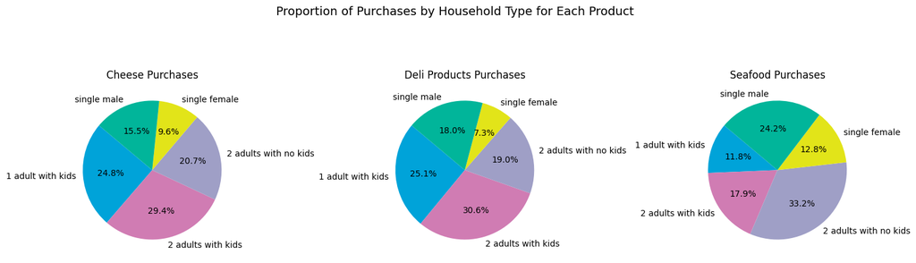

```python
### Pie charts for Household Type purchases

household_color_map = {
    'single male': brand_colors['sea green'],
    'single female': brand_colors['chartreuse'],
    '1 adult with kids': brand_colors['deep sky blue'],
    '2 adults with kids': brand_colors['orchid'],
    '2 adults with no kids': brand_colors['lt periwinkle'],
}

# Group data by commodity and household type, and count the number of purchases
hh_purchase_counts = focus_purchases.groupby(['commodity', 'household_type']).size().reset_index(name='purchase_count')

# Calculate total purchases per commodity
total_hh_counts = hh_purchase_counts.groupby('commodity')['purchase_count'].transform('sum')

# Calculate proportions
hh_purchase_counts['proportion'] = hh_purchase_counts['purchase_count'] / total_hh_counts

# Get unique commodities
commodities = hh_purchase_counts['commodity'].unique()

# Create pie charts
fig, axes = plt.subplots(1, len(commodities), figsize=(15, 5))  # Create subplots for pie charts

for idx, commodity in enumerate(commodities):
    # Filter data for the current commodity
    data = hh_purchase_counts[hh_purchase_counts['commodity'] == commodity]

    # Map household types to colors
    colors = [household_color_map[household] for household in data['household_type']]


    # Create pie chart
    axes[idx].pie(
        data['proportion'],  # Values
        labels=data['household_type'],  # Labels
        autopct='%1.1f%%',  # Display percentages
        startangle=140,  # Starting angle for better visualization
        colors=colors
    )
    # Add a title
    axes[idx].set_title(f'{commodity.title()} Purchases')

# Adjust layout
plt.suptitle('Proportion of Purchases by Household Type for Each Product', fontsize=14)
plt.tight_layout(rect=[0, 0, 1, 0.95])

# Show the plot
plt.show()
```

#### No obvious household type to focus on

### Pie charts for Age band purchases

```python
### Pie charts for Age band purchases

age_color_map = {
    '19-24': brand_colors['sea green'],
    '25-34': brand_colors['chartreuse'],
    '35-44': brand_colors['deep sky blue'],
    '45-54': brand_colors['orchid'],
    '55-64': brand_colors['lt periwinkle'],
    'Greater than 65': brand_colors['lt peacoat']
}

# Group data by commodity and age band, and count the number of purchases
age_purchase_counts = focus_purchases.groupby(['commodity', 'age_band']).size().reset_index(name='purchase_count')

# Remove "Greater than 65" age group - it was causing label overlap issues and had a non-visible slice of the pie
age_purchase_counts = age_purchase_counts[age_purchase_counts['age_band'] != 'Greater than 65']

# Calculate total purchases per commodity
total_age_counts = age_purchase_counts.groupby('commodity')['purchase_count'].transform('sum')

# Calculate proportions
age_purchase_counts['proportion'] = age_purchase_counts['purchase_count'] / total_age_counts

# Get unique commodities
commodities = age_purchase_counts['commodity'].unique()

# Create pie charts
fig, axes = plt.subplots(1, len(commodities), figsize=(15, 5))  # Create subplots for pie charts

for idx, commodity in enumerate(commodities):
    # Filter data for the current commodity
    data = age_purchase_counts[age_purchase_counts['commodity'] == commodity]

    # Map ages to colors
    colors = [age_color_map[age] for age in data['age_band']]


    # Create pie chart
    axes[idx].pie(
        data['proportion'],  # Values
        labels=data['age_band'],  # Labels
        autopct='%1.1f%%',  # Display percentages
        startangle=140,  # Starting angle for better visualization
        colors=colors,
        labeldistance=1.1,  # Increase label distance from the pie
        pctdistance=0.7  # Adjust percentage label position
    )
    # Add a title
    axes[idx].set_title(f'{commodity.title()} Purchases')

# Adjust layout
plt.suptitle('Proportion of Purchases by Age Band for Each Product', fontsize=24)
plt.tight_layout(rect=[0, 0, 1, 0.95])

# Show the plot
#plt.show()

# Save the chart as an image file
filename = f'.\\Charts\\age_pie.png'
plt.tight_layout()
plt.savefig(filename, dpi=300)
plt.close()

print("Charts Saved")
```

```
Charts Saved
```

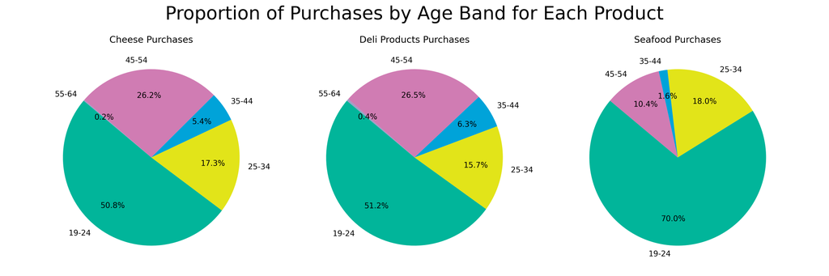

### Sales Revenue Chart

```python
### Full years sales revenue
rev_fullyears_reset = rev_fullyears.reset_index()

def currency_format(x, _):
    return f'${x:,.2f}'

plt.figure(figsize=(10, 6))

# Create bar chart
sns.barplot(x='year', y='total_revenue', data=rev_fullyears_reset, color=brand_colors['lt sky blue'])

#add bar labels
for index, row in rev_fullyears_reset.iterrows():
    plt.text(x=index,
             y=row['total_revenue'] + 0.01 * max(rev_fullyears_reset['total_revenue']),  # Adjust position slightly above the bar
             s=f"${row['total_revenue']:,.2f}",
             ha='center')  # Center the text horizontally


plt.xlabel('Year')
plt.ylabel('Total Revenue')
plt.gca().yaxis.set_major_formatter(FuncFormatter(currency_format))  # Apply currency format to y-axis

# Show the plot
# plt.show()

# Save the chart as an image file
filename = f'.\\Charts\\full_year_rev.png'
plt.tight_layout()
plt.savefig(filename, dpi=300)
plt.close()

print("Charts Saved")
```

```
Charts Saved
```

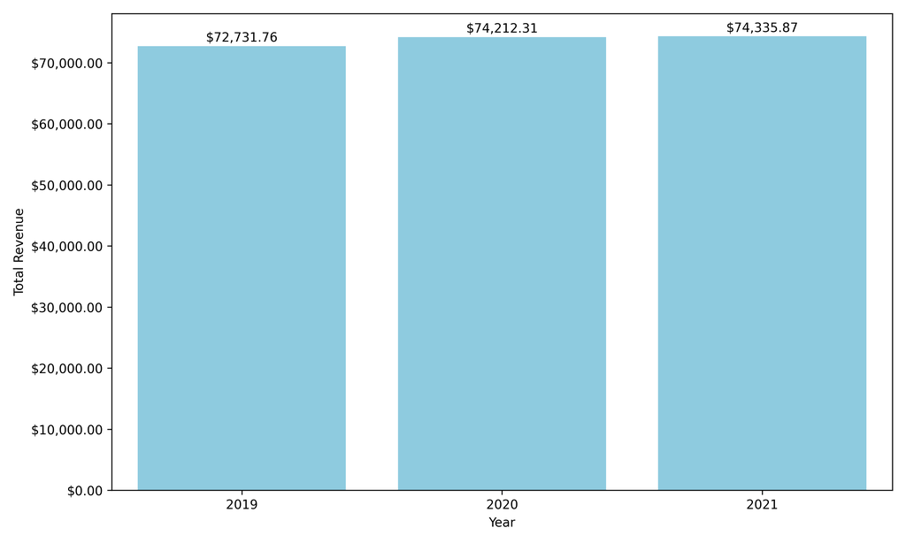

### Compare Sales revenue for first 5 months of all 4 years

```python
### Ytd sales revenue
rev_ytd_reset = rev_ytd.reset_index()

def currency_format(x, _):
    return f'${x:,.2f}'

plt.figure(figsize=(10, 6))

# Create bar chart
sns.barplot(x='year', y='total_revenue', data=rev_ytd_reset, color=brand_colors['lt periwinkle'])

#add bar labels
for index, row in rev_ytd_reset.iterrows():
    plt.text(x=index,
             y=row['total_revenue'] + 0.01 * max(rev_ytd_reset['total_revenue']),  # Adjust position slightly above the bar
             s=f"${row['total_revenue']:,.2f}",
             ha='center')  # Center the text horizontally


plt.xlabel('Year')
plt.ylabel('Total Revenue')
plt.gca().yaxis.set_major_formatter(FuncFormatter(currency_format))  # Apply currency format to y-axis

# Show the plot
#plt.show()

# Save the chart as an image file
filename = f'.\\Charts\\ytd_rev.png'
plt.tight_layout()
plt.savefig(filename, dpi=300)
plt.close()

print("Charts Saved")
```

```
Charts Saved
```

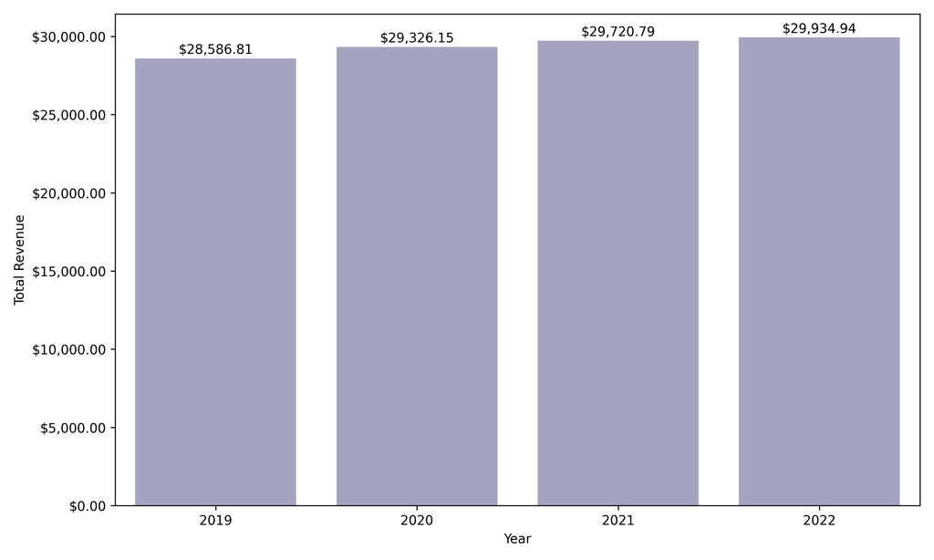

### Show total baskets per year have stayed consistent

```python
### Total baskets per full year
# Create bar chart
sns.barplot(x='year', y='total_baskets', data=tot_bc)

#add bar labels
for index, row in tot_bc.iterrows():
    plt.text(x=index,
             y=row['total_baskets'] + 0.01 * max(tot_bc['total_baskets']),  # Adjust position slightly above the bar
             s=f"{row['total_baskets']:,}",
             ha='center')  # Center the text horizontally

plt.title('Total Basket Counts - Last 3 Full Years')
plt.xlabel('Year')
plt.ylabel('Total Basket Count')

# Show the plot
#plt.show()

# Save the chart as an image file
filename = f'.\\Charts\\total_baskets.png'
plt.tight_layout()
plt.savefig(filename, dpi=300)
plt.close()

print("Charts Saved")
```

```
Charts Saved
```

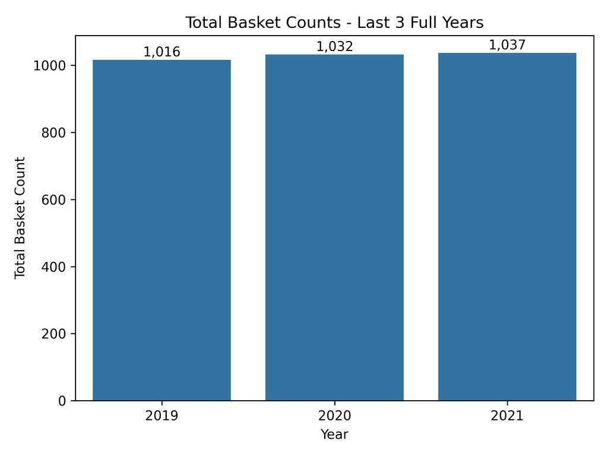

### Create data set for ytd comparison of revenue for focus products

```python
### Create data set for ytd comparison of revenue for focus products
focus_rev = focus_purchases.groupby(['year', 'month', 'commodity']).agg(total_revenue=('price', 'sum')).reset_index()
#focus_rev.head(50)

# Create list to collect monthly data
all_months = []


for month in fm:
# Filter data for the specific month
    focus_ytd_data = focus_rev[focus_rev['month'] == month].reset_index(drop=True)
    #Append data to the list
    all_months.append(focus_ytd_data)

# Add all monthly data into one dataframe
combined_ytd = pd.concat(all_months, ignore_index = True)

focus_ytd_rev = combined_ytd.groupby(['year', 'commodity']).agg(ytd_revenue=('total_revenue', 'sum')) \
    .sort_values(['year', 'ytd_revenue'], ascending=[True,False]).reset_index()
focus_ytd_rev.head(25)

#focus_rev.head(50)
```

|  | year | commodity | ytd_revenue |
| --- | --- | --- | --- |
| 0 | 2019 | seafood | 1554.35 |
| 1 | 2019 | cheese | 672.61 |
| 2 | 2019 | deli products | 560.00 |
| 3 | 2020 | seafood | 1035.32 |
| 4 | 2020 | cheese | 693.32 |
| 5 | 2020 | deli products | 628.28 |
| 6 | 2021 | seafood | 1229.89 |
| 7 | 2021 | deli products | 795.16 |
| 8 | 2021 | cheese | 751.06 |
| 9 | 2022 | seafood | 1725.97 |
| 10 | 2022 | deli products | 993.28 |
| 11 | 2022 | cheese | 748.73 |

### Chart revenue of focus products for the first 5 months of each year in the data set

```python
### Revenue of focus products ytd

def currency_format(x, _):
    return f'${x:,.2f}'


# Map commodities to specific brand colors
commodity_color_map2 = {
    'cheese': brand_colors['chartreuse'],
    'cereals': brand_colors['peacoat'],
    'deli products': brand_colors['deep sky blue'],
    'seafood': brand_colors['lt orchid']
}

plt.figure(figsize=(12, 6))

sns.barplot(
    data=focus_ytd_rev,
    x='year',
    y='ytd_revenue',
    hue='commodity',
    palette=commodity_color_map2
)

plt.title('Total Revenue from Focus Products - YTD Comparison', fontsize=24)
plt.xlabel('Year', fontsize=16)
plt.ylabel('Total Revenue', fontsize=16)
plt.gca().yaxis.set_major_formatter(FuncFormatter(currency_format))  # Apply currency format to y-axis
plt.legend(title='Commodity', bbox_to_anchor=(1.05, 1), loc='upper left')
plt.xticks(fontsize=10)
plt.yticks(fontsize=10)

# Save the chart as an image file
filename = f'.\\Charts\\focus_ytd_rev.png'
plt.tight_layout()
plt.savefig(filename, dpi=300)
plt.close()

print("Charts Saved")

#plt.tight_layout()
#plt.show()
```

```
Charts Saved
```

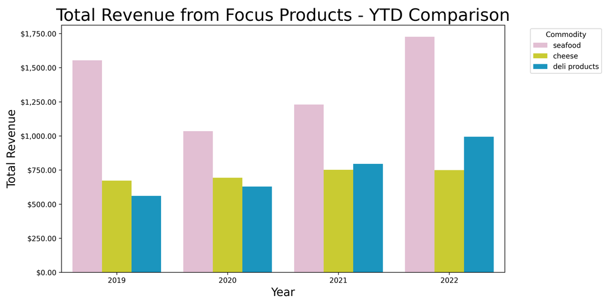

### Average monthly revenue for each of the focus products since 2019

```python
### Average monthly revenue for each of the focus products since 2019

focus_avg_mr = focus_rev.groupby(['commodity']).agg(avg_mr = ('total_revenue', 'mean')).reset_index()
focus_avg_mr['avg_mr'] = focus_avg_mr['avg_mr'].round(2)
focus_avg_mr.head()
```

|  | commodity | avg_mr |
| --- | --- | --- |
| 0 | cheese | 155.42 |
| 1 | deli products | 145.85 |
| 2 | seafood | 221.97 |

### Average spend per basket for each of the focus products for the last 6 months

```python
### Average spend per basket for each of the focus products for the last 6 months

# This will give the data we need to know how many additional purchases
# we need to increase monthly in order to reach our revenue goals

# Find total basket count, total monthly revenue, and average basket revenue for each focus product for each month
focus_month_stats = focus_purchases.groupby(['year', 'month', 'commodity']).agg(total_baskets=('basket_id', 'nunique'), \
    total_revenue=('price', 'sum')).reset_index()
focus_month_stats['avg_basket_price']=focus_month_stats['total_revenue'] / focus_month_stats['total_baskets']
#focus_month_stats.head(50)

#Find average basket price for each focus product for the last 6 months
focus_month_stats_last6 = focus_month_stats.tail(18).reset_index(drop=True)
#focus_month_stats_last6.head(20)
focus_avgbp_last6 = focus_month_stats_last6.groupby(['commodity']).agg(avg_rev=('avg_basket_price', 'mean')).reset_index()
focus_avgbp_last6.head()
```

|  | commodity | avg_rev |
| --- | --- | --- |
| 0 | cheese | 4.040302 |
| 1 | deli products | 5.491975 |
| 2 | seafood | 8.135134 |

### Required revenue increase calculation

```python
### Required revenue increase

# Using non-compounded values
# Decision to take an average of the last six months monthly revenue to calculate necessary
# increases to mitigate effects of seasonality and ensure more realistic targets

# Monthly revenue in last month of data
tot_monthly_rev = tot_monthly_rev.sort_values(['year', 'month'])

# Limit to last 6 months
last_6 = tot_monthly_rev.tail(6)

avg_mr = last_6['monthly_rev'].mean()
req_increase = avg_mr * .025
print(f"Average monthly revenue for the last 6 months: ${avg_mr:,.2f}")
print(f"Required monthly revenue increase to achieve goal: ${req_increase:,.2f}")
```

```
Average monthly revenue for the last 6 months: $6,217.77
Required monthly revenue increase to achieve goal: $155.44
```

#### Goal will be to increase monthly revenue by $155.44

### How many additional cheese, deli and seafood purchases do we need per month to achieve our goal?

```python
### This will give me the total if I am only increasing purchases for a single product

# Take our monthly revenue increase goal and divide by average monthly basket for our focus products
focus_avgbp_last6['new_purchases'] = req_increase / focus_avgbp_last6['avg_rev']
focus_avgbp_last6['no_new_purchases'] = focus_avgbp_last6['new_purchases'].apply(math.ceil)
focus_avgbp_last6.head()
```

|  | commodity | avg_rev | new_purchases | no_new_purchases |
| --- | --- | --- | --- | --- |
| 0 | cheese | 4.040302 | 38.473392 | 39 |
| 1 | deli products | 5.491975 | 28.303866 | 29 |
| 2 | seafood | 8.135134 | 19.107753 | 20 |

```python
### I want to work out what proportion of new purchases should be allocated to each product
focus_avgbp_last6_prop = focus_avgbp_last6

# Calculate the proportion of the total revenue goal for each product
focus_avgbp_last6_prop['proportional_goal'] = (focus_avgbp_last6['avg_rev'] / focus_avgbp_last6['avg_rev'].sum()) * req_increase

# Calculate the number of new purchases needed for each product
focus_avgbp_last6_prop['new_purchases'] = focus_avgbp_last6['proportional_goal'] / focus_avgbp_last6_prop['avg_rev']
focus_avgbp_last6_prop['new_purchases'] = focus_avgbp_last6['new_purchases'].apply(math.ceil)  # Round up to ensure the goal is met
focus_avgbp_last6_prop.head()
```

|  | commodity | avg_rev | new_purchases | no_new_purchases | proportional_goal |
| --- | --- | --- | --- | --- | --- |
| 0 | cheese | 4.040302 | 9 | 39 | 35.548005 |
| 1 | deli products | 5.491975 | 9 | 29 | 48.320337 |
| 2 | seafood | 8.135134 | 9 | 20 | 71.575782 |

### Increase Cheese, Deli and Seafood purchases by 9 each month

### How many additional shops per month are required by customers in the 19-24 age group to achieve our goal?

```python
### How many additional shops per month are required by customers in the 19-24 age group to achieve our goal?

# First I need to find the average basket total for shoppers in the 19-24 age band over the last 6 months

# Filter data for just rows with 19-24 age band
focus_age = df1[df1['age_band'].isin(['19-24'])]

#
focus_age_baskets = focus_age.groupby(['year', 'month', 'basket_id']).agg(total_basket_price = ('price', 'sum')).reset_index()

last_6_months = ['20225', '20224', '20223', '20222', '20221', '202112']
#print (last_6_months)

# Find all rows with a concatenation of year and month that match the last_6_months

focus_age_baskets['date_code']= focus_age_baskets['year'].astype(str) + focus_age_baskets['month'].astype(str)
focus_age_baskets_l6 = focus_age_baskets[focus_age_baskets['date_code'].isin(last_6_months)].reset_index(drop=True)

# Now find the average basket price for each month

focus_age_l6_avgs = focus_age_baskets_l6.groupby(['year', 'month']).agg(average_price=('total_basket_price', 'mean')).reset_index()
focus_age_basket_avg = focus_age_l6_avgs['average_price'].mean()
print (f"The average basket price over the last 6 months for the 19-24 age group is: ${focus_age_basket_avg:.2f}")
#focus_age_l6_avgs.head(300)
```

```
The average basket price over the last 6 months for the 19-24 age group is: $74.72
```